# Day-2

Muhammad Farooq

2022-08-26

## This notebook is about statistical methods and their use in our research.

###**List of basic statistical methods** 1- Shapiro wilk’s Method 2- t.test (independent, Paired) 3- ANOVA (One way ANOVA and TWO way ANOVA) 4- ANCOVA 5- MANOVA 6- MANCOVA 7- wilcoxon Rank 8- Mann whitney U test 9- Correlation (Pearson and Spearman) 10-Krukshul walis test 11-Regression (Correlation) 12-PostHoc Analysis (Multiple Comparison of Means)

### Check the normal distribution of the data

```r
iris
```

```
##     Sepal.Length Sepal.Width Petal.Length Petal.Width    Species
## 1            5.1         3.5          1.4         0.2     setosa
## 2            4.9         3.0          1.4         0.2     setosa
## 3            4.7         3.2          1.3         0.2     setosa
## 4            4.6         3.1          1.5         0.2     setosa
## 5            5.0         3.6          1.4         0.2     setosa
## 6            5.4         3.9          1.7         0.4     setosa
## 7            4.6         3.4          1.4         0.3     setosa
## 8            5.0         3.4          1.5         0.2     setosa
## 9            4.4         2.9          1.4         0.2     setosa
## 10           4.9         3.1          1.5         0.1     setosa
## 11           5.4         3.7          1.5         0.2     setosa
## 12           4.8         3.4          1.6         0.2     setosa
## 13           4.8         3.0          1.4         0.1     setosa
## 14           4.3         3.0          1.1         0.1     setosa
```

[output cut: 136 more lines]

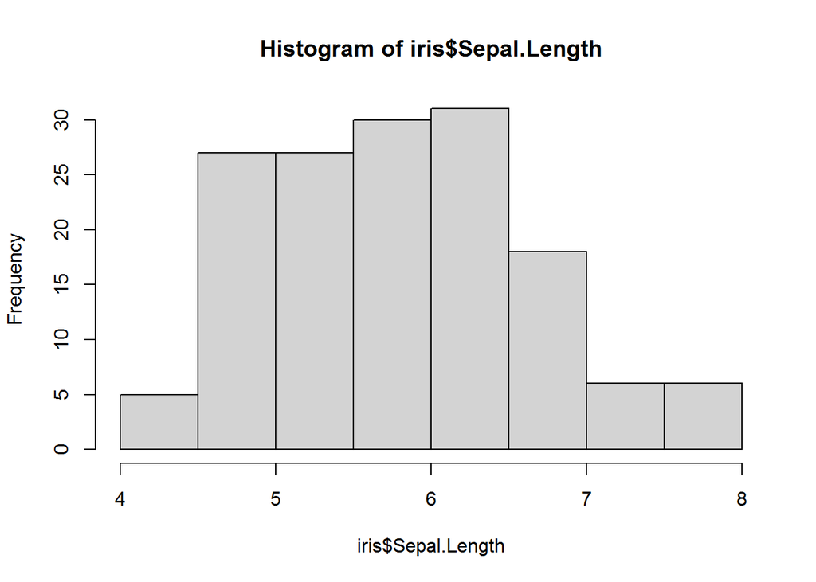

```r
hist(iris$Sepal.Length)
```

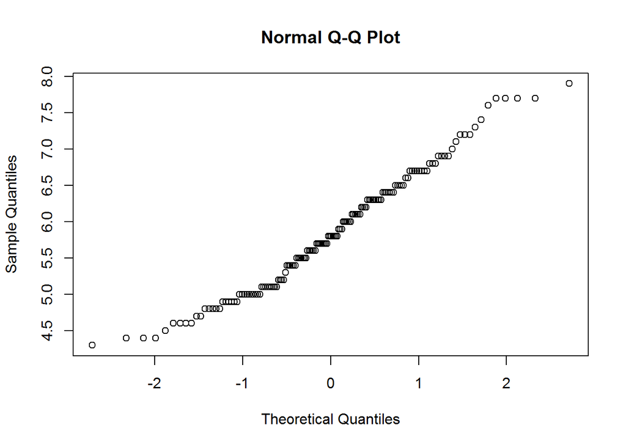

```r
qqnorm(iris$Sepal.Length)
```

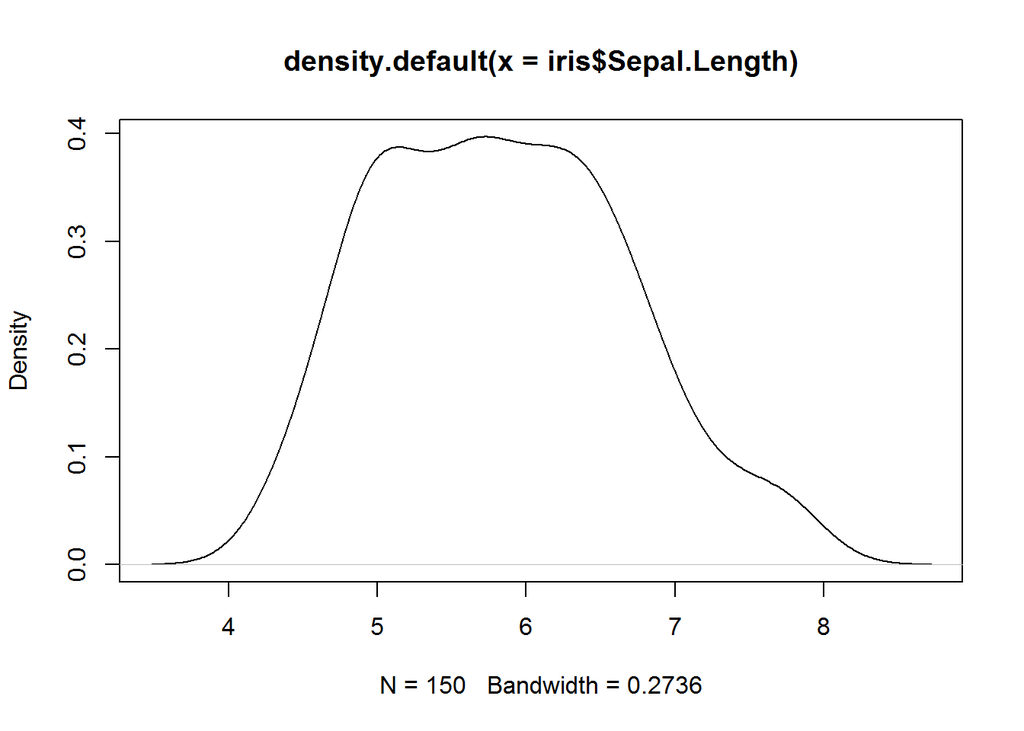

```r
x <- density(iris$Sepal.Length)
plot(x)
```

All these plots can tell us visually if the data is normally distributed. Another method is to test with Shapiro Wilk’s method

```r
shapiro.test(iris$Sepal.Length)
```

```
##
##  Shapiro-Wilk normality test
##
## data:  iris$Sepal.Length
## W = 0.97609, p-value = 0.01018
```

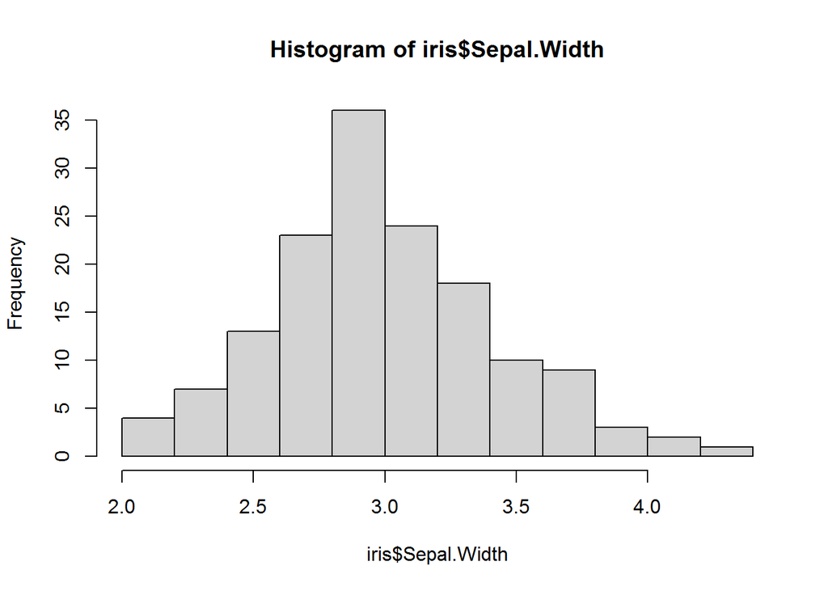

```r
hist(iris$Sepal.Width)
```

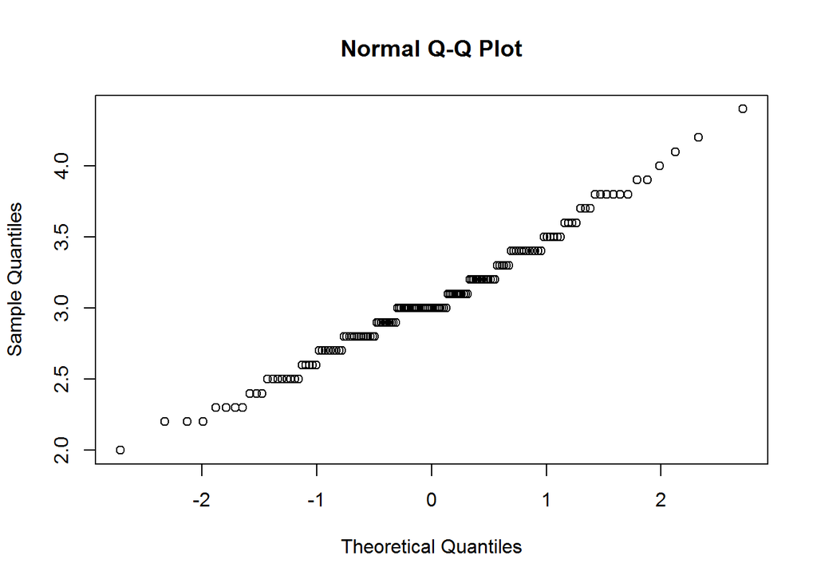

```r
qqnorm(iris$Sepal.Width)
```

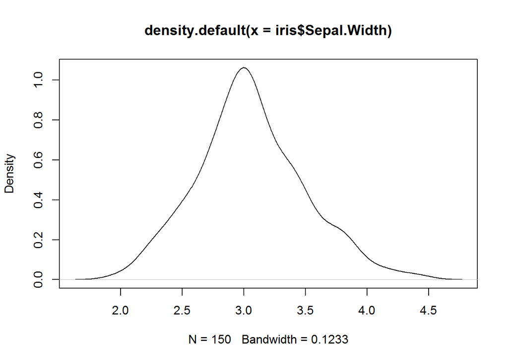

```r
y <- density(iris$Sepal.Width)
plot(y)
```

```r
shapiro.test(iris$Sepal.Width)
```

```
##
##  Shapiro-Wilk normality test
##
## data:  iris$Sepal.Width
## W = 0.98492, p-value = 0.1012
```

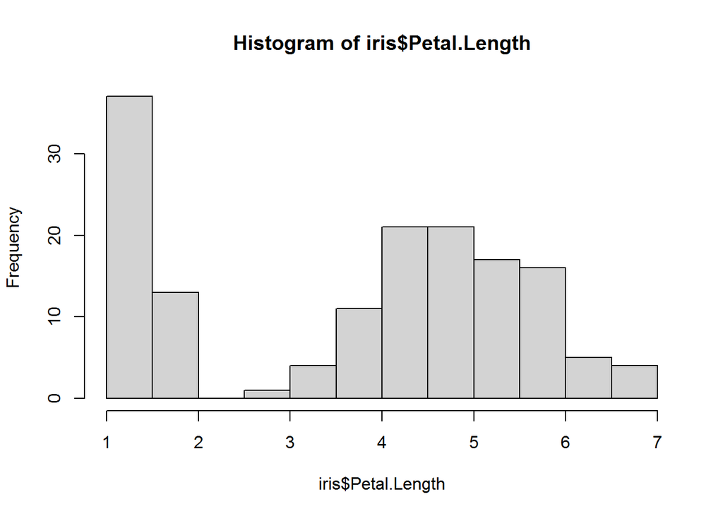

```r
hist(iris$Petal.Length)
```

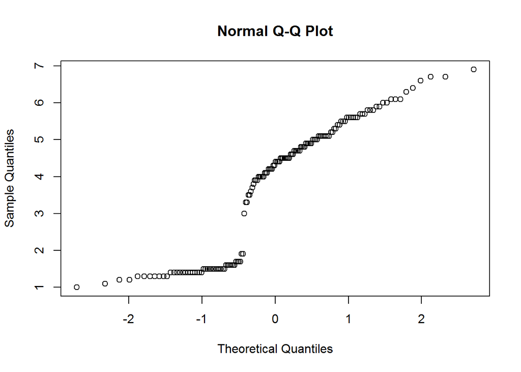

```r
qqnorm(iris$Petal.Length)
```

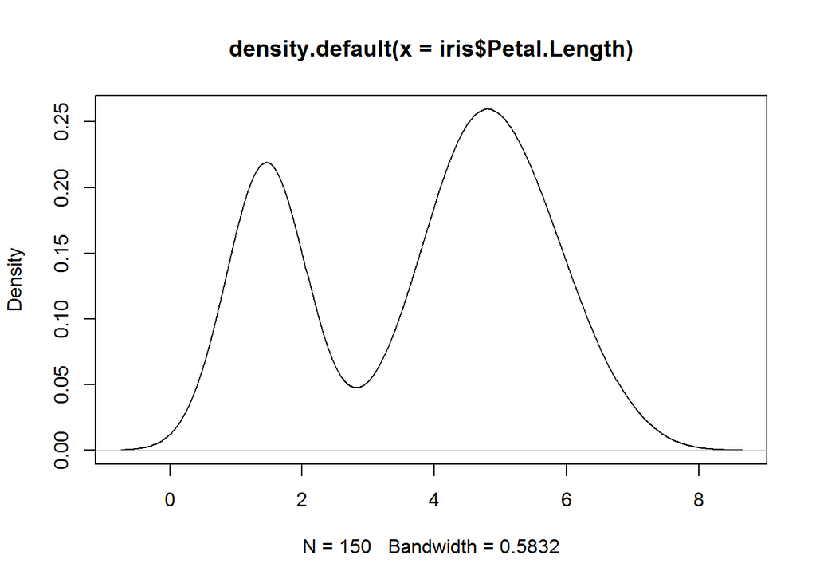

```r
z <- density(iris$Petal.Length)
plot(z)
```

```r
shapiro.test(iris$Petal.Length)
```

```
##
##  Shapiro-Wilk normality test
##
## data:  iris$Petal.Length
## W = 0.87627, p-value = 7.412e-10
```

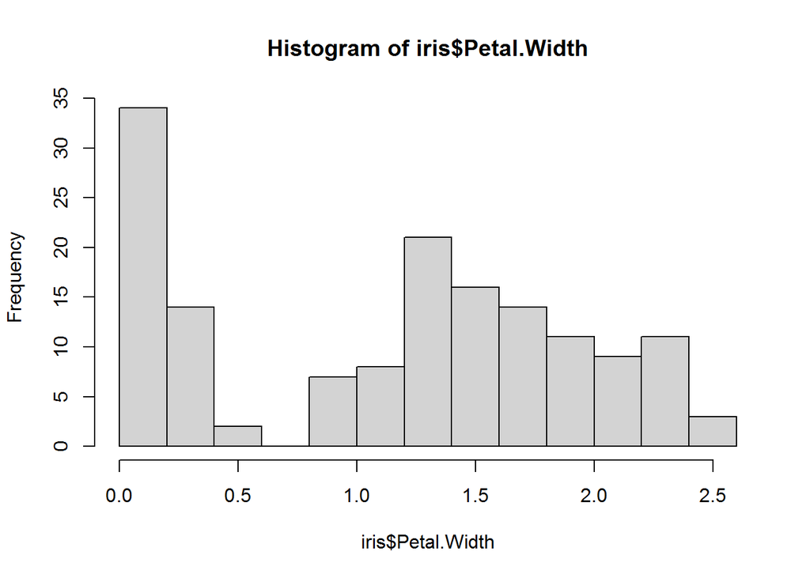

```r
hist(iris$Petal.Width)
```

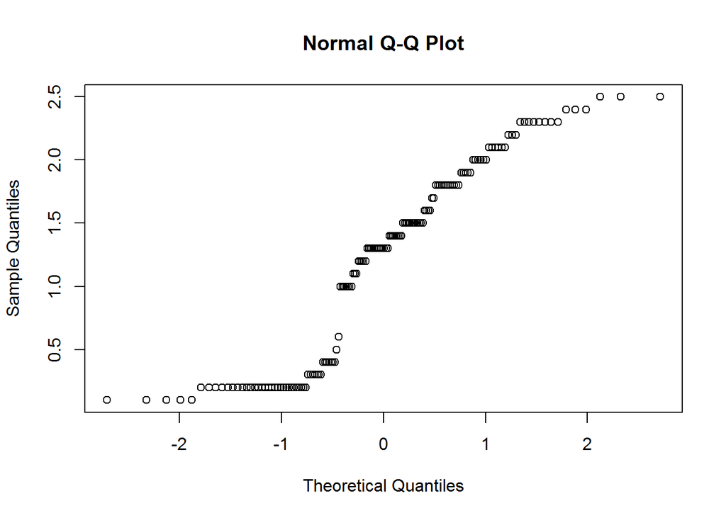

```r
qqnorm(iris$Petal.Width)
```

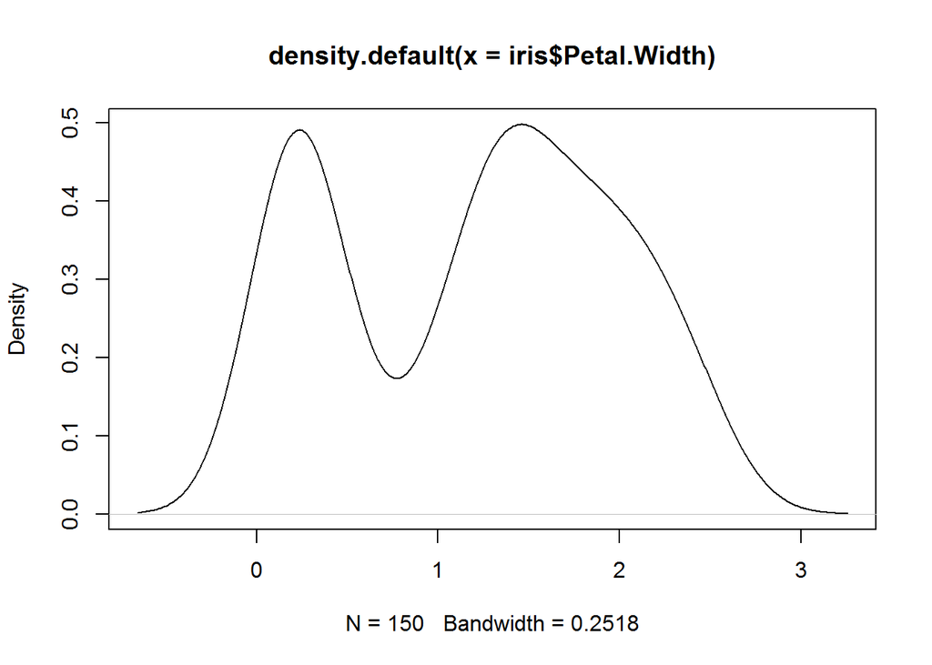

```r
z1 <- density(iris$Petal.Width)
plot(z1)
```

```r
shapiro.test(iris$Petal.Width)
```

```
##
##  Shapiro-Wilk normality test
##
## data:  iris$Petal.Width
## W = 0.90183, p-value = 1.68e-08
```

##t.test ###one sample t.test

```r
t.test(iris$Sepal.Length, mu=0)
```

```
##
##  One Sample t-test
##
## data:  iris$Sepal.Length
## t = 86.425, df = 149, p-value < 2.2e-16
## alternative hypothesis: true mean is not equal to 0
## 95 percent confidence interval:
##  5.709732 5.976934
## sample estimates:
## mean of x
##  5.843333
```

```r
t.test(iris$Sepal.Length, iris$Sepal.Width)
```

```
##
##  Welch Two Sample t-test
##
## data:  iris$Sepal.Length and iris$Sepal.Width
## t = 36.463, df = 225.68, p-value < 2.2e-16
## alternative hypothesis: true difference in means is not equal to 0
## 95 percent confidence interval:
##  2.63544 2.93656
## sample estimates:
## mean of x mean of y
##  5.843333  3.057333
```

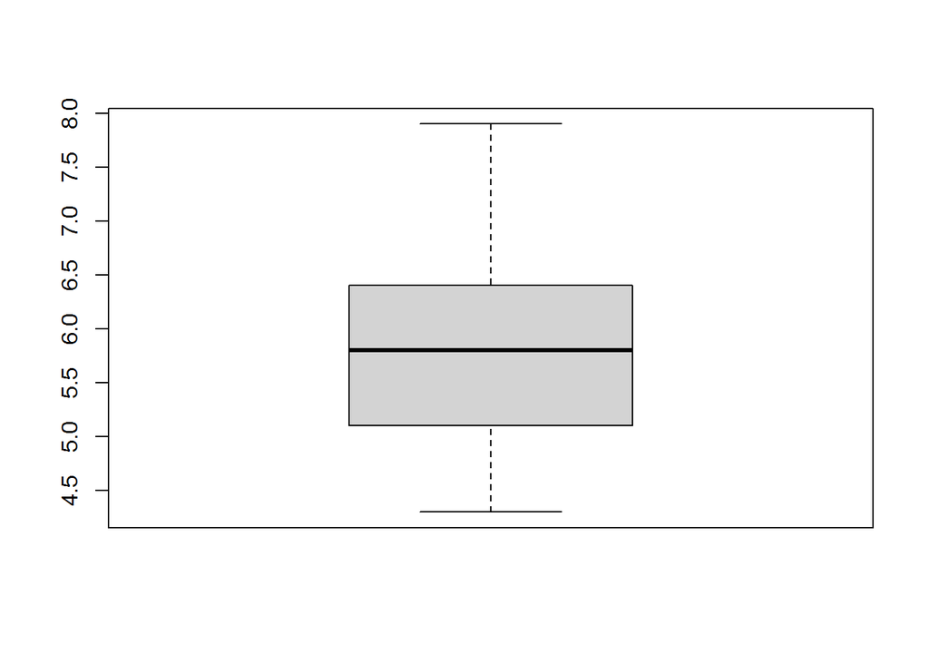

```r
boxplot(iris$Sepal.Length)
```

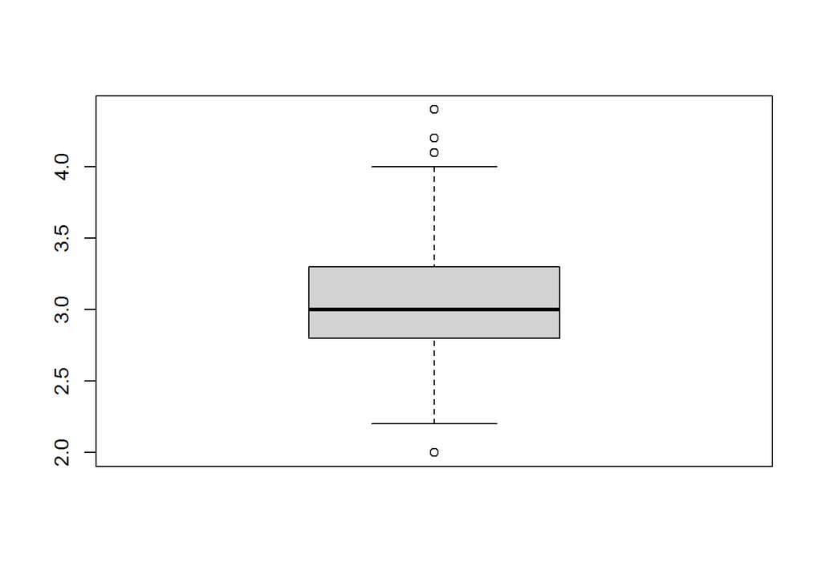

```r
boxplot(iris$Sepal.Width)
```

###Tow sample t.test for independent variable (one numeric and one binary factor)

```r
x <- subset(iris, iris$Species=="virginica" | iris$Species=="setosa")
x
```

```
##     Sepal.Length Sepal.Width Petal.Length Petal.Width   Species
## 1            5.1         3.5          1.4         0.2    setosa
## 2            4.9         3.0          1.4         0.2    setosa
## 3            4.7         3.2          1.3         0.2    setosa
## 4            4.6         3.1          1.5         0.2    setosa
## 5            5.0         3.6          1.4         0.2    setosa
## 6            5.4         3.9          1.7         0.4    setosa
## 7            4.6         3.4          1.4         0.3    setosa
## 8            5.0         3.4          1.5         0.2    setosa
## 9            4.4         2.9          1.4         0.2    setosa
## 10           4.9         3.1          1.5         0.1    setosa
## 11           5.4         3.7          1.5         0.2    setosa
## 12           4.8         3.4          1.6         0.2    setosa
## 13           4.8         3.0          1.4         0.1    setosa
## 14           4.3         3.0          1.1         0.1    setosa
```

[output cut: 86 more lines]

```r
t.test(x$Sepal.Length ~ x$Species)
```

```
##
##  Welch Two Sample t-test
##
## data:  x$Sepal.Length by x$Species
## t = -15.386, df = 76.516, p-value < 2.2e-16
## alternative hypothesis: true difference in means between group setosa and group virginica is not equal to 0
## 95 percent confidence interval:
##  -1.78676 -1.37724
## sample estimates:
##    mean in group setosa mean in group virginica
##                   5.006                   6.588
```

### Paired t.test (both should be numeric variables)

```r
t.test(x$Sepal.Length, x$Sepal.Width, paired = TRUE)
```

```
##
##  Paired t-test
##
## data:  x$Sepal.Length and x$Sepal.Width
## t = 23.313, df = 99, p-value < 2.2e-16
## alternative hypothesis: true mean difference is not equal to 0
## 95 percent confidence interval:
##  2.375048 2.816952
## sample estimates:
## mean difference
##           2.596
```

###we have to write these p-values in the following order: p<0.05 *, p<0.01 **, p<0.001*** ,